# Athlete_exploratory_analysis

Sergi Crespi

2022-11-04

# 1 File reading

```r
gpa <- read.csv("gpa_clean.csv")
```

Verifying variable types:

```r
str(gpa)
```

```
## 'data.frame':    4137 obs. of  11 variables:
##  $ sat      : int  920 1170 810 940 1180 980 880 980 1240 1230 ...
##  $ tothrs   : int  43 18 14 40 18 114 78 55 18 17 ...
##  $ hsize    : num  0.1 9.4 1.19 5.71 2.14 ...
##  $ hsrank   : int  4 191 42 252 86 41 161 101 161 3 ...
##  $ hsperc   : num  40 20.3 35.3 44.1 40.2 ...
##  $ colgpa   : num  2.04 4 1.78 2.42 2.61 ...
##  $ athlete  : logi  TRUE FALSE TRUE FALSE FALSE FALSE ...
##  $ female   : logi  TRUE FALSE FALSE FALSE FALSE TRUE ...
##  $ white    : logi  FALSE TRUE TRUE TRUE TRUE TRUE ...
##  $ black    : logi  FALSE FALSE FALSE FALSE FALSE FALSE ...
##  $ gpaletter: chr  "C" "A" "C" "C" ...
```

```r
summary(gpa)
```

```
##       sat           tothrs           hsize          hsrank
##  Min.   : 470   Min.   :  6.00   Min.   :0.03   Min.   :  1.00
##  1st Qu.: 940   1st Qu.: 17.00   1st Qu.:1.65   1st Qu.: 11.00
##  Median :1030   Median : 47.00   Median :2.51   Median : 30.00
##  Mean   :1030   Mean   : 52.83   Mean   :2.80   Mean   : 52.83
##  3rd Qu.:1120   3rd Qu.: 80.00   3rd Qu.:3.68   3rd Qu.: 70.00
##  Max.   :1540   Max.   :137.00   Max.   :9.40   Max.   :634.00
##      hsperc            colgpa       athlete          female
##  Min.   : 0.1667   Min.   :0.000   Mode :logical   Mode :logical
##  1st Qu.: 6.4328   1st Qu.:2.210   FALSE:3943      FALSE:2277
##  Median :14.5833   Median :2.660   TRUE :194       TRUE :1860
##  Mean   :19.2371   Mean   :2.654
##  3rd Qu.:27.7108   3rd Qu.:3.120
##  Max.   :92.0000   Max.   :4.000
##    white           black          gpaletter
##  Mode :logical   Mode :logical   Length:4137
##  FALSE:308       FALSE:3908      Class :character
##  TRUE :3829      TRUE :229       Mode  :character
##
##
##
```

# 2 Descriptive analysis and visualization

### 2.1 Descriptive analysis

```r
dim(gpa)
```

```
## [1] 4137   11
```

4137 observations and 11 variables. Taking a closer look to the numeric and categorical variables:

```r
summary(gpa)
```

```
##       sat           tothrs           hsize          hsrank
##  Min.   : 470   Min.   :  6.00   Min.   :0.03   Min.   :  1.00
##  1st Qu.: 940   1st Qu.: 17.00   1st Qu.:1.65   1st Qu.: 11.00
##  Median :1030   Median : 47.00   Median :2.51   Median : 30.00
##  Mean   :1030   Mean   : 52.83   Mean   :2.80   Mean   : 52.83
##  3rd Qu.:1120   3rd Qu.: 80.00   3rd Qu.:3.68   3rd Qu.: 70.00
##  Max.   :1540   Max.   :137.00   Max.   :9.40   Max.   :634.00
##      hsperc            colgpa       athlete          female
##  Min.   : 0.1667   Min.   :0.000   Mode :logical   Mode :logical
##  1st Qu.: 6.4328   1st Qu.:2.210   FALSE:3943      FALSE:2277
##  Median :14.5833   Median :2.660   TRUE :194       TRUE :1860
##  Mean   :19.2371   Mean   :2.654
##  3rd Qu.:27.7108   3rd Qu.:3.120
##  Max.   :92.0000   Max.   :4.000
##    white           black          gpaletter
##  Mode :logical   Mode :logical   Length:4137
##  FALSE:308       FALSE:3908      Class :character
##  TRUE :3829      TRUE :229       Mode  :character
##
##
##
```

### 2.2 Visualization

#### 2.2.1 sat and colgpa distribution

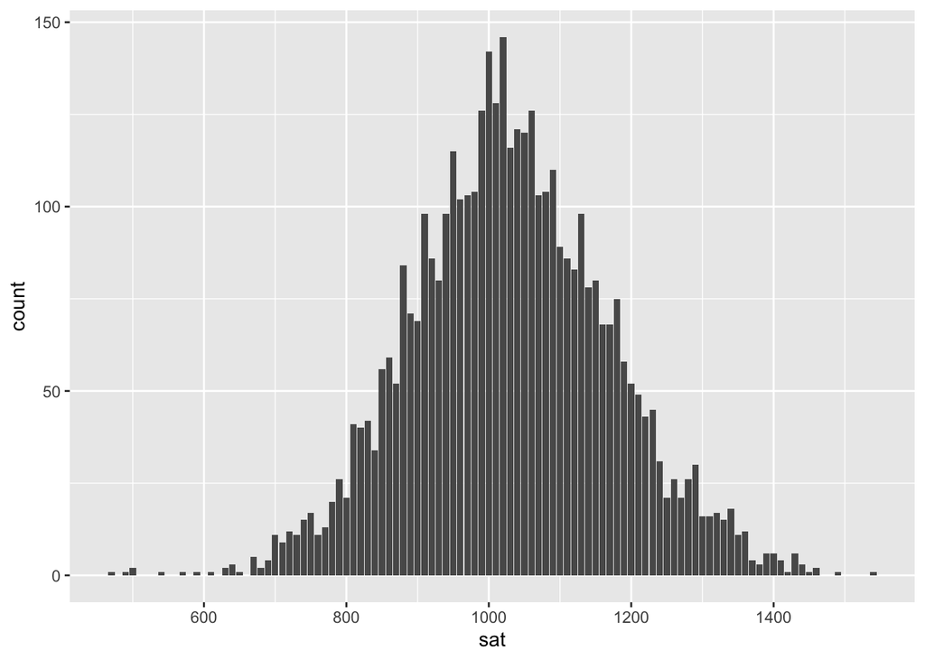

```r
if (!require('ggplot2')) install.packages('ggplot2'); library('ggplot2')
ggplot(data=gpa, aes(x = sat)) +
  geom_bar()
```

sat has a normal distribution.

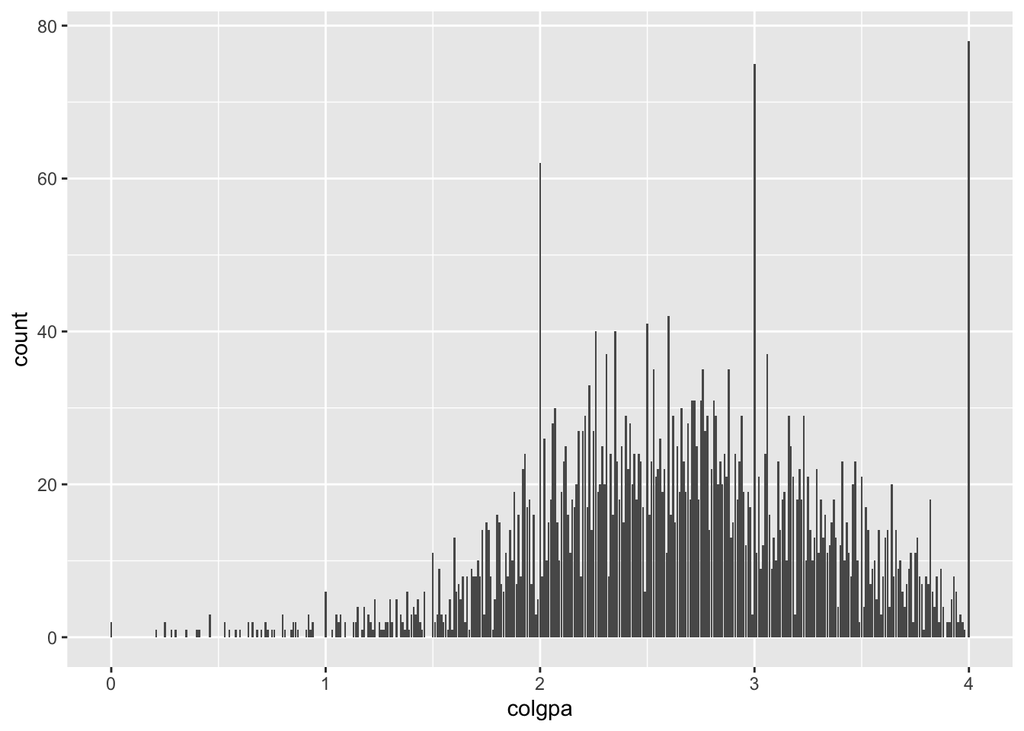

```r
if (!require('ggplot2')) install.packages('ggplot2'); library('ggplot2')
ggplot(data=gpa, aes(x = colgpa)) +
  geom_bar()
```

colgpa has a normal distirbution with outliers and atypical values.

#### 2.2.2 Variable sat with variable genre (“female”), variable athlece (“athlete”) and variable race (“white”,“black”)

Genre:

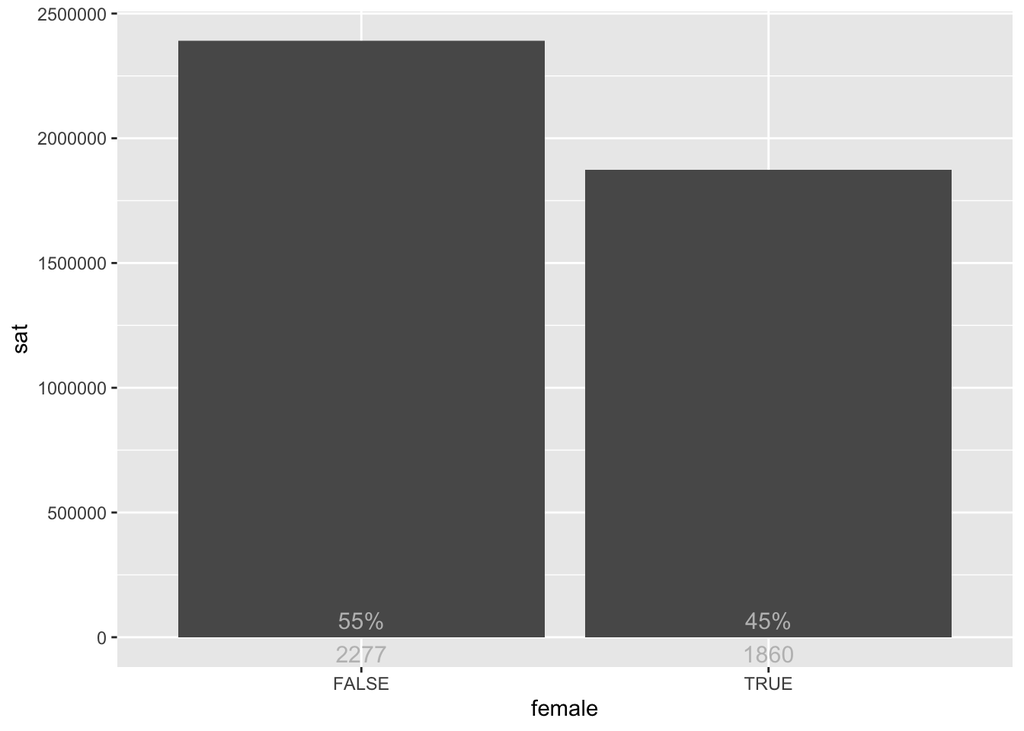

```r
if (!require('ggplot2')) install.packages('ggplot2'); library('ggplot2')
ggplot(data=gpa, aes(x = female, y = sat)) +
  geom_bar(stat = "identity") +
  stat_count(aes(label=paste0(sprintf("%1.f", ..count../sum(..count..)*100),
                              "%\n", ..count..), y=0.5*..count..),
             geom="text", colour="grey", size=4, position=position_dodge(width=.9))
```

1860 samples (45%) is female. Plotting an histogram:

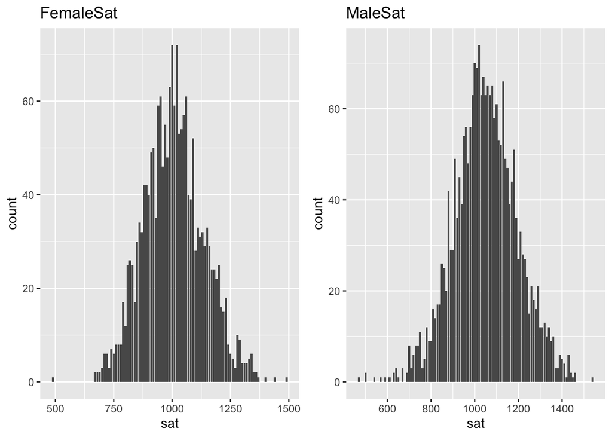

```r
if (!require('gridExtra')) install.packages('gridExtra'); library('gridExtra')
femalegpa <- gpa[which(gpa$female==TRUE),]
p1 <- ggplot(data=femalegpa, aes(x = sat)) +
  geom_bar() + ggtitle("FemaleSat")
malegpa <- gpa[which(gpa$female==FALSE),]
p2 <- ggplot(data=malegpa, aes(x = sat)) +
  geom_bar() + ggtitle("MaleSat")
grid.arrange(p1, p2, nrow=1)
```

Proceeding the same way for the variable athlete:

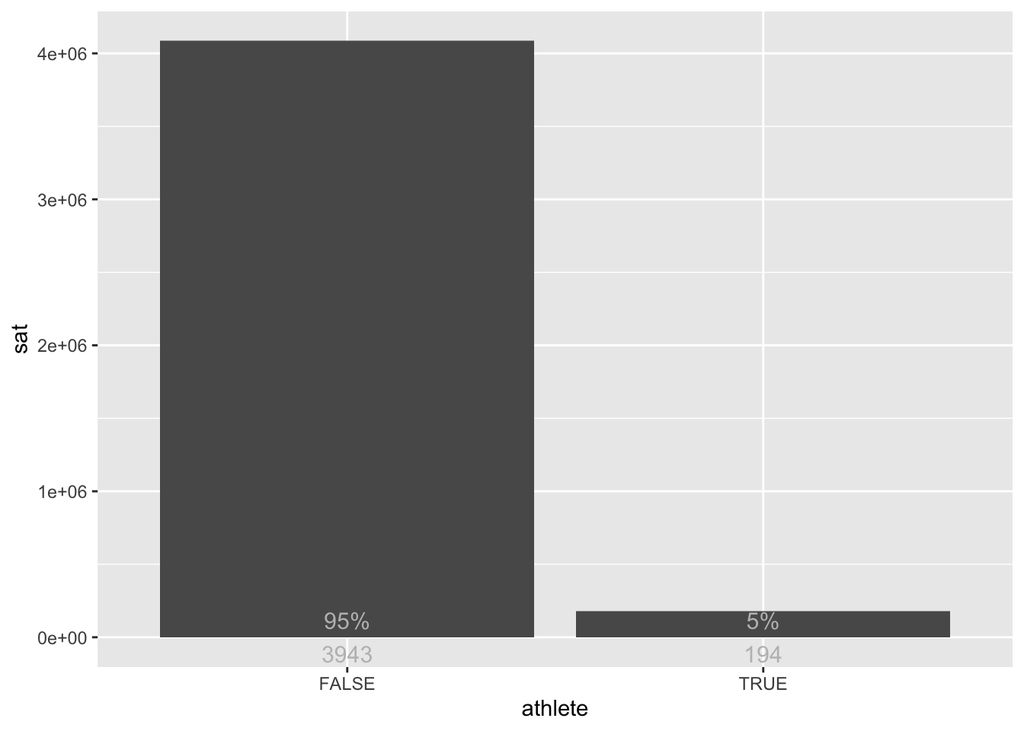

```r
ggplot(data=gpa, aes(x = athlete, y = sat)) +
  geom_bar(stat = "identity") +
  stat_count(aes(label=paste0(sprintf("%1.f", ..count../sum(..count..)*100),
                              "%\n", ..count..), y=0.5*..count..),
             geom="text", colour="grey", size=4, position=position_dodge(width=.9))
```

194 samples, 5%, are athletes. Let’s see the distribution between athlete and non athlete:

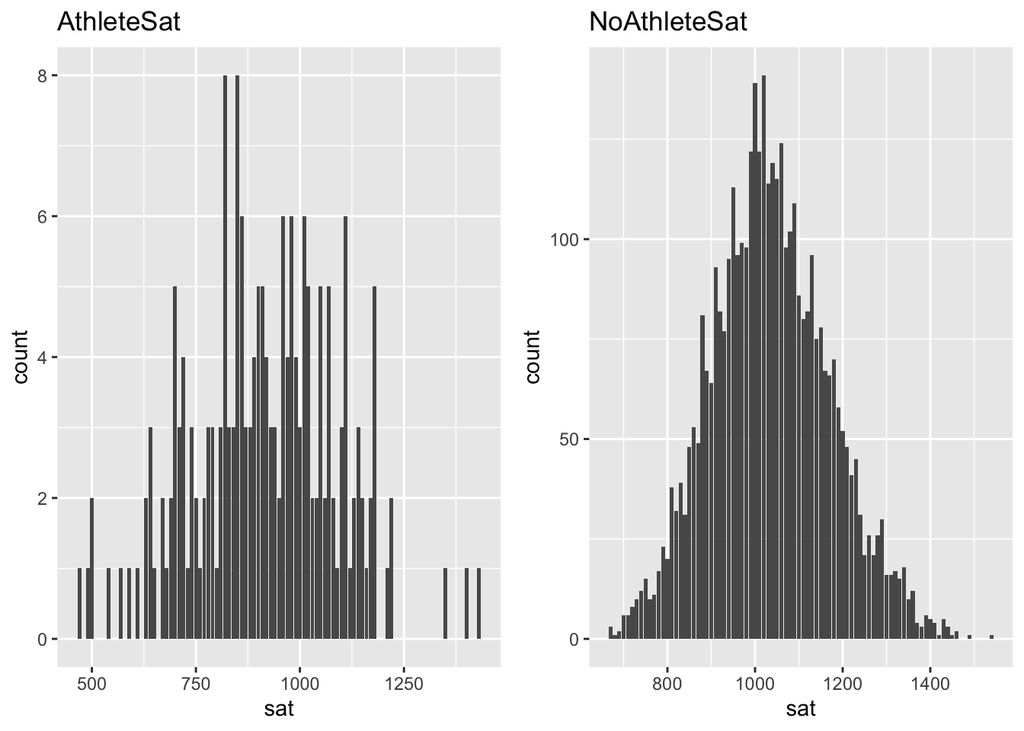

```r
athletegpa <- gpa[which(gpa$athlete==TRUE),]
p3 <- ggplot(data=athletegpa, aes(x = sat)) +
  geom_bar() + ggtitle("AthleteSat")
noathletegpa <- gpa[which(gpa$athlete==FALSE),]
p4 <- ggplot(data=noathletegpa, aes(x = sat)) +
  geom_bar() + ggtitle("NoAthleteSat")
grid.arrange(p3, p4, nrow=1)
```

Proceeding the same way for gender, starting with thie.

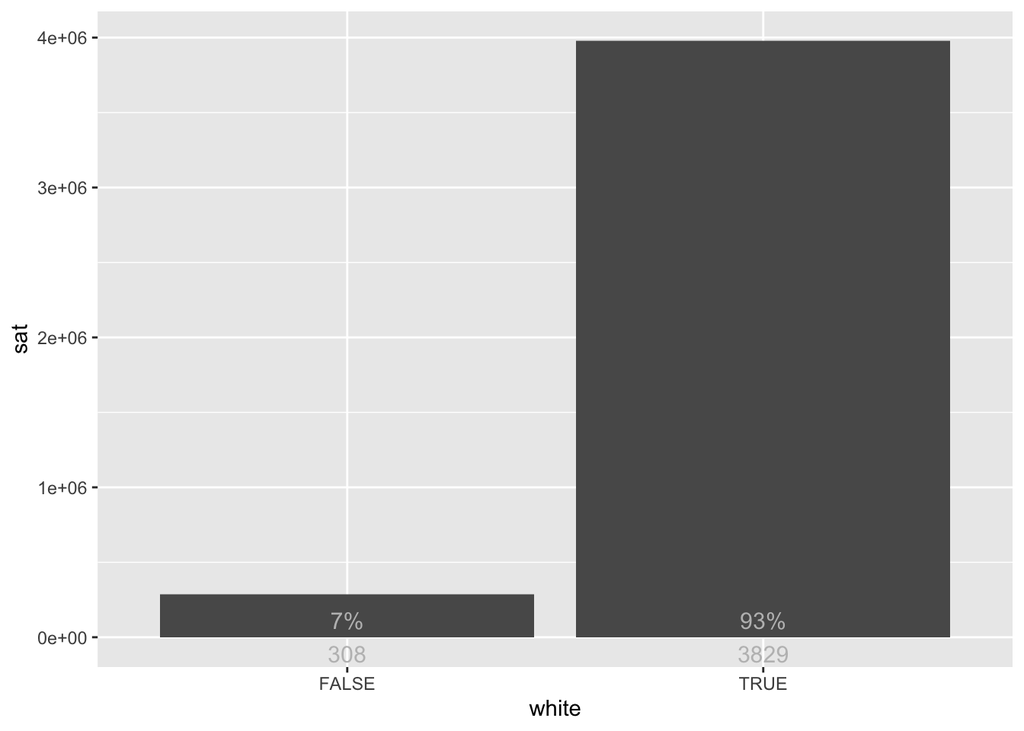

```r
ggplot(data=gpa, aes(x = white, y = sat)) +
  geom_bar(stat = "identity") +
  stat_count(aes(label=paste0(sprintf("%1.f", ..count../sum(..count..)*100),
                              "%\n", ..count..), y=0.5*..count..),
             geom="text", colour="grey", size=4, position=position_dodge(width=.9))
```

[figure not shown]

```r
whitegpa <- gpa[which(gpa$white==TRUE),]
p5 <- ggplot(data=whitegpa, aes(x = sat)) +
  geom_bar() + ggtitle("WhiteSat")
nowhitegpa <- gpa[which(gpa$athlete==FALSE),]
p6 <- ggplot(data=nowhitegpa, aes(x = sat)) +
  geom_bar() + ggtitle("NoWhiteSat")
grid.arrange(p5, p6, nrow=1)
```

Proceeding the same way for gender, with black:

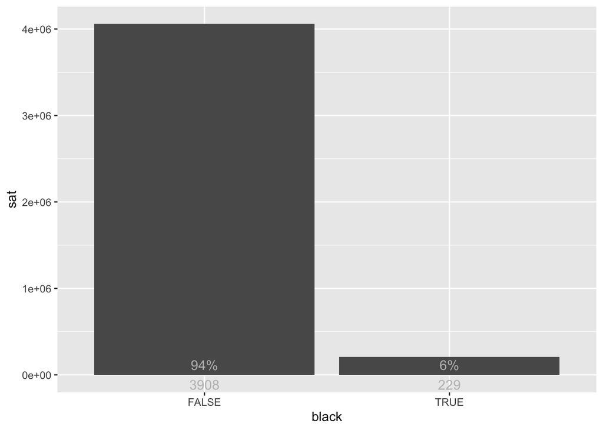

```r
ggplot(data=gpa, aes(x = black, y = sat)) +
  geom_bar(stat = "identity") +
  stat_count(aes(label=paste0(sprintf("%1.f", ..count../sum(..count..)*100),
                              "%\n", ..count..), y=0.5*..count..),
             geom="text", colour="grey", size=4, position=position_dodge(width=.9))
```

229 samples, 6%, belong to that race. 79 samples, 1%, are neither black nor white. Let’s see black distribution:

[figure not shown]

```r
blackgpa <- gpa[which(gpa$black==TRUE),]
p7 <- ggplot(data=whitegpa, aes(x = sat)) +
  geom_bar() + ggtitle("BlackSat")
noblackgpa <- gpa[which(gpa$black==FALSE),]
p8 <- ggplot(data=noblackgpa, aes(x = sat)) +
  geom_bar() + ggtitle("NoBlackSat")
grid.arrange(p7, p8, nrow=1)
```

Showcasing an alternative way to portray distributions:

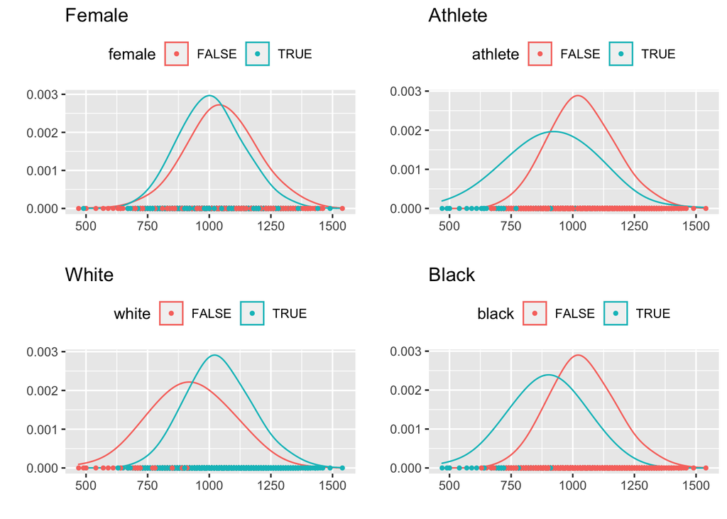

```r
if (!require('dplyr')) install.packages('dplyr'); library('dplyr')
N=nrow(gpa)
y=rep(0,N)
y1<-data.frame(y)
names(y1)<-"ceros"
gpa2 <-bind_cols(gpa, y1)

p9<-ggplot(gpa2)+
  geom_density(aes(x= sat), adjust=2) +
  aes(colour = female) +
    labs(title="Female", y=" ", x="  " ) +
  theme(legend.position = "top")         +
  geom_point(aes(x=sat, y=ceros),  size=1)

p10<-ggplot(gpa2)+
  geom_density(aes(x= sat), adjust=2) +
  aes(colour = athlete) +
    labs(title="Athlete", y=" ", x="  " ) +
  theme(legend.position = "top")         +
  geom_point(aes(x=sat, y=ceros),  size=1)

p11<-ggplot(gpa2)+
  geom_density(aes(x= sat), adjust=2) +
  aes(colour = white) +
    labs(title="White", y=" ", x=" " ) +
  theme(legend.position = "top")         +
  geom_point(aes(x=sat, y=ceros),  size=1)

p12<-ggplot(gpa2)+
  geom_density(aes(x= sat), adjust=2) +
  aes(colour = black) +
    labs(title="Black", y=" ", x=" " ) +
  theme(legend.position = "top")         +
  geom_point(aes(x=sat, y=ceros),  size=1)

grid.arrange(p9, p10, p11, p12, ncol=2)
```

#### 2.2.3 Variable volgpa with variable genre (“female”), variable atleta (“athlete”) and race (“white”,“black”)

We’ll proceed the same way than before:

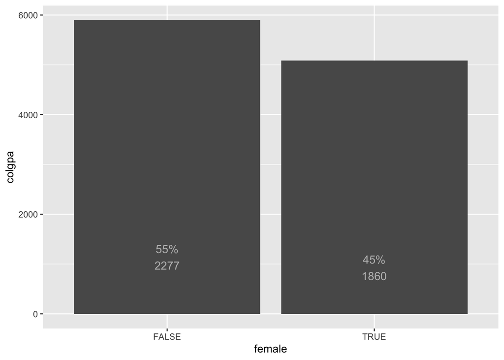

```r
ggplot(data=gpa, aes(x = female, y =colgpa)) +
  geom_bar(stat = "identity") +
  stat_count(aes(label=paste0(sprintf("%1.f", ..count../sum(..count..)*100),
                              "%\n", ..count..), y=0.5*..count..),
             geom="text", colour="grey", size=4, position=position_dodge(width=.9))
```

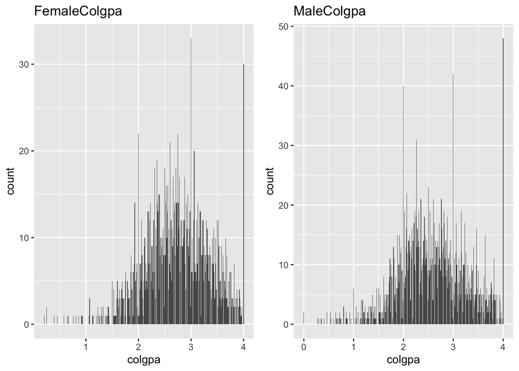

```r
femalecolgpa <- gpa[which(gpa$female==TRUE),]
p13 <- ggplot(data=femalecolgpa, aes(x = colgpa)) +
  geom_bar() + ggtitle("FemaleColgpa")
malecolgpa <- gpa[which(gpa$female==FALSE),]
p14 <- ggplot(data=malecolgpa, aes(x = colgpa)) +
  geom_bar() + ggtitle("MaleColgpa")
grid.arrange(p13, p14, nrow=1)
```

Athlete:

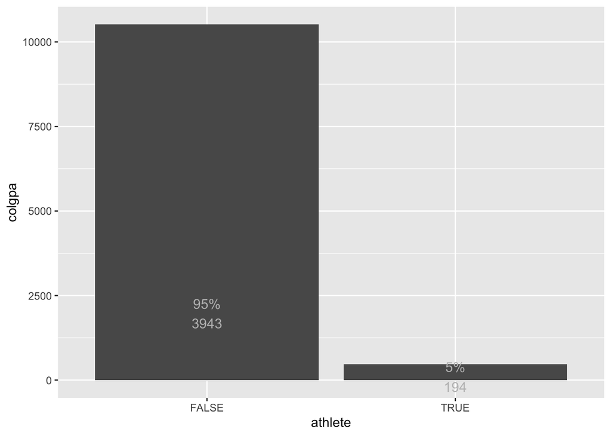

```r
ggplot(data=gpa, aes(x = athlete, y =colgpa)) +
  geom_bar(stat = "identity") +
  stat_count(aes(label=paste0(sprintf("%1.f", ..count../sum(..count..)*100),
                              "%\n", ..count..), y=0.5*..count..),
             geom="text", colour="grey", size=4, position=position_dodge(width=.9))
```

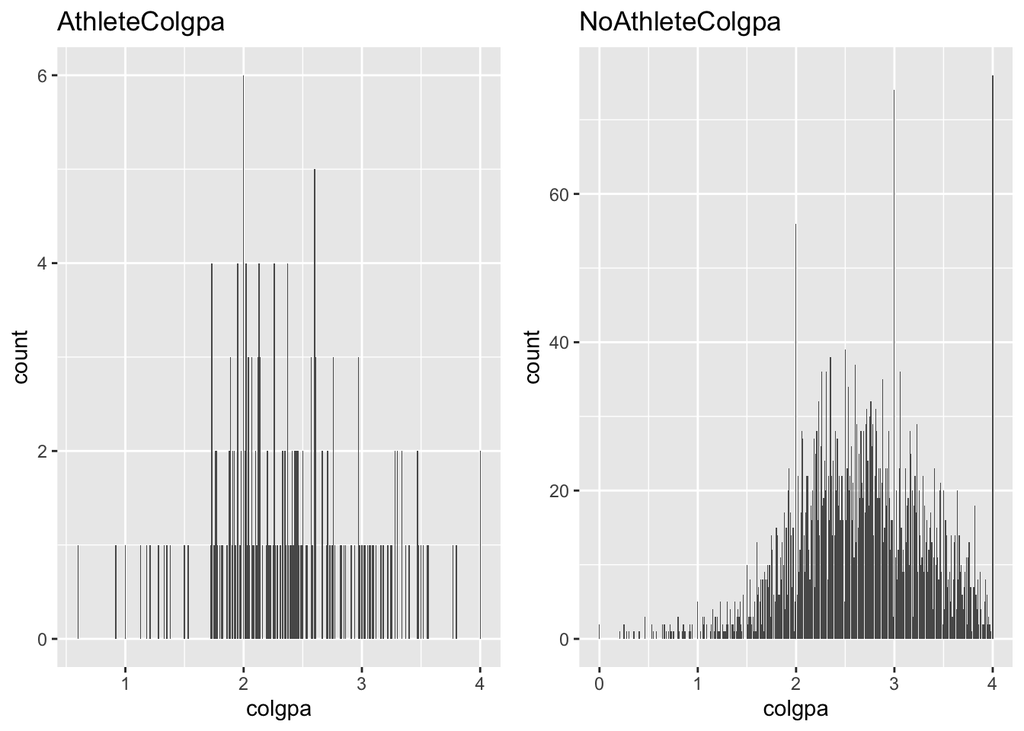

```r
athletecolgpa <- gpa[which(gpa$athlete==TRUE),]
p15 <- ggplot(data=athletecolgpa, aes(x = colgpa)) +
  geom_bar() + ggtitle("AthleteColgpa")
noathletecolgpa <- gpa[which(gpa$athlete==FALSE),]
p16 <- ggplot(data=noathletecolgpa, aes(x = colgpa)) +
  geom_bar() + ggtitle("NoAthleteColgpa")
grid.arrange(p15, p16, nrow=1)
```

White:

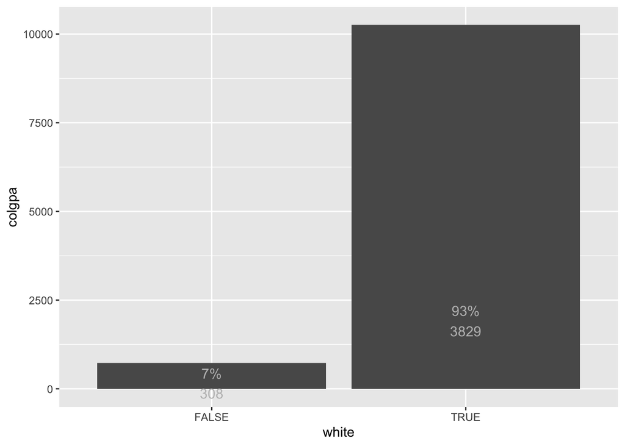

```r
ggplot(data=gpa, aes(x = white, y =colgpa)) +
  geom_bar(stat = "identity") +
  stat_count(aes(label=paste0(sprintf("%1.f", ..count../sum(..count..)*100),
                              "%\n", ..count..), y=0.5*..count..),
             geom="text", colour="grey", size=4, position=position_dodge(width=.9))
```

Seeing the distribution:

[figure not shown]

```r
whitecolgpa <- gpa[which(gpa$white==TRUE),]
p17 <- ggplot(data=whitecolgpa, aes(x = colgpa)) +
  geom_bar() + ggtitle("WhiteColgpa")
nowhitecolgpa <- gpa[which(gpa$athlete==FALSE),]
p18 <- ggplot(data=nowhitecolgpa, aes(x = colgpa)) +
  geom_bar() + ggtitle("NoWhiteColgpa")
grid.arrange(p17, p18, nrow=1)
```

Black:

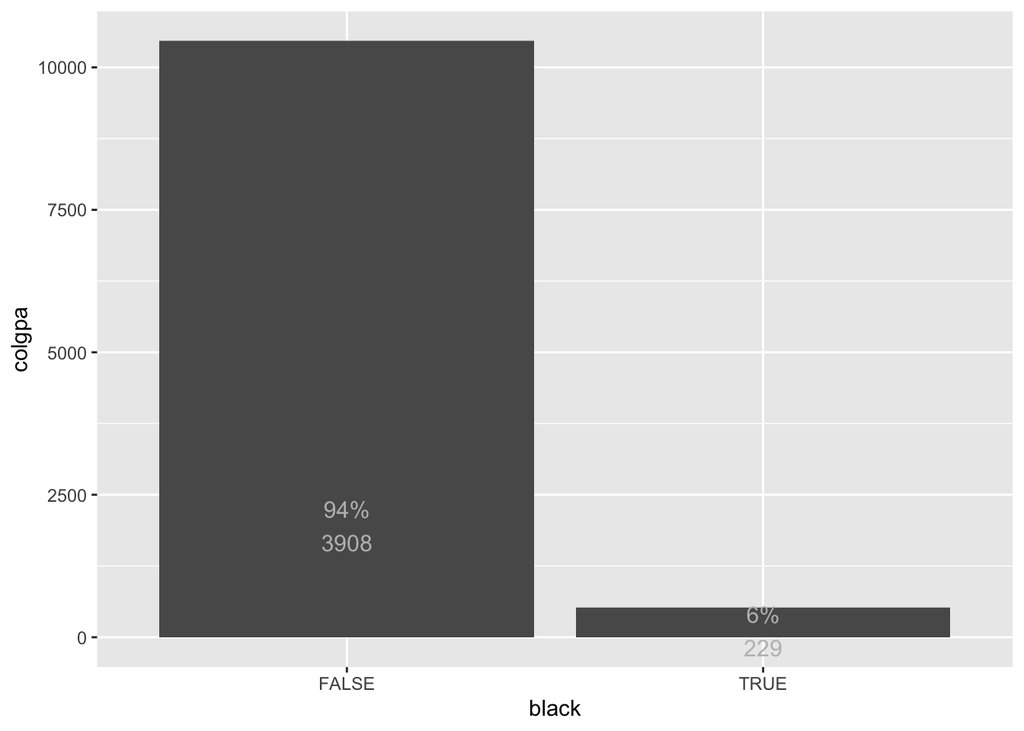

```r
ggplot(data=gpa, aes(x = black, y =colgpa)) +
  geom_bar(stat = "identity") +
  stat_count(aes(label=paste0(sprintf("%1.f", ..count../sum(..count..)*100),
                              "%\n", ..count..), y=0.5*..count..),
             geom="text", colour="grey", size=4, position=position_dodge(width=.9))
```

Seeing the distribution:

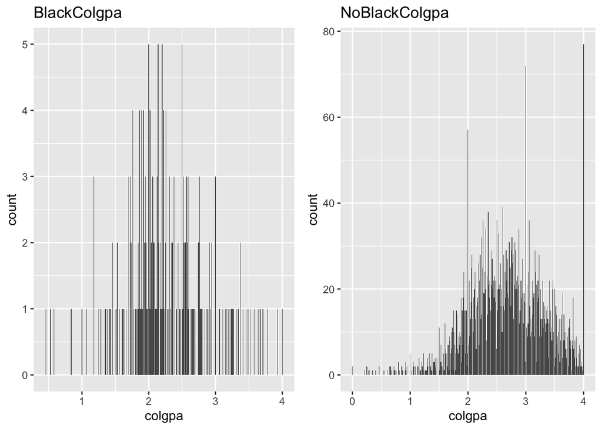

```r
blackcolgpa <- gpa[which(gpa$black==TRUE),]
p19 <- ggplot(data=blackcolgpa, aes(x = colgpa)) +
  geom_bar() + ggtitle("BlackColgpa")
noblackcolgpa <- gpa[which(gpa$black==FALSE),]
p20 <- ggplot(data=noblackcolgpa, aes(x = colgpa)) +
  geom_bar() + ggtitle("NoBlackColgpa")
grid.arrange(p19, p20, nrow=1)
```

Showcasing an alternate way to show distributions:

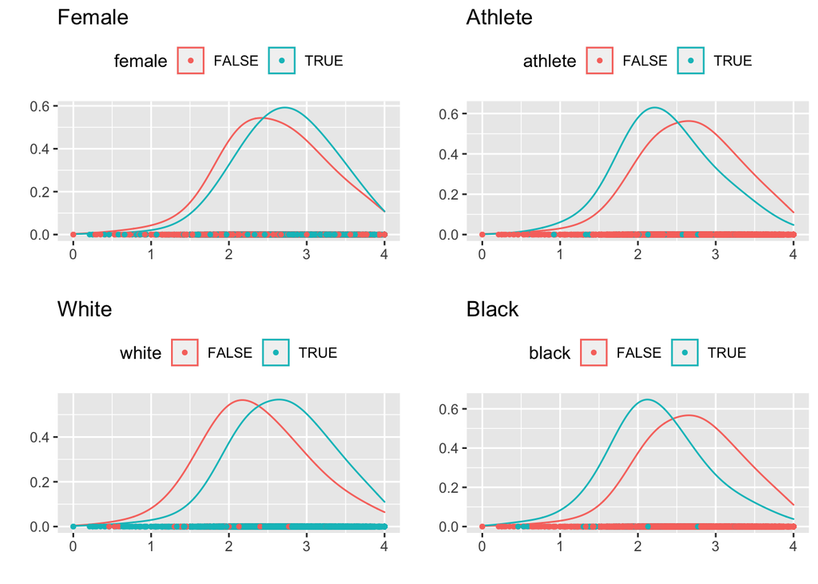

```r
p21<-ggplot(gpa2)+
  geom_density(aes(x= colgpa), adjust=2) +
  aes(colour = female) +
    labs(title="Female", y=" ", x="  " ) +
  theme(legend.position = "top")         +
  geom_point(aes(x=colgpa, y=ceros),  size=1)

p22<-ggplot(gpa2)+
  geom_density(aes(x= colgpa), adjust=2) +
  aes(colour = athlete) +
    labs(title="Athlete", y=" ", x="  " ) +
  theme(legend.position = "top")         +
  geom_point(aes(x=colgpa, y=ceros),  size=1)

p23<-ggplot(gpa2)+
  geom_density(aes(x= colgpa), adjust=2) +
  aes(colour = white) +
    labs(title="White", y=" ", x=" " ) +
  theme(legend.position = "top")         +
  geom_point(aes(x=colgpa, y=ceros),  size=1)

p24<-ggplot(gpa2)+
  geom_density(aes(x= colgpa), adjust=2) +
  aes(colour = black) +
    labs(title="Black", y=" ", x=" " ) +
  theme(legend.position = "top")         +
  geom_point(aes(x=colgpa, y=ceros),  size=1)

grid.arrange(p21, p22, p23, p24, ncol=2)
```

# 3 Confidence interval of the population mean between variable sat and colgpa

### 3.1 Assumptions

sat and colgpa has normal distributions and we would like to know their standard deviation, the average… we want to know the 95% confidence interval of the grades from the students in the data sample.

### 3.2 Calculating confidence interval

Implementing a function that calculates the confidence interval of a variable and the desired level of confidence:

```r
IC <- function(x, NC){
  n <- length(x)
  alfa <- 1-(NC/100)
  sd <- sd(x)
  SE <- sd / sqrt(n)

  t <- qt(alfa/2, df=n-1, lower.tail=FALSE)
  L <- mean(x) - t*SE
  U <- mean(x) + t*SE
  return(c(L,U))
}
```

### 3.3 Confidence interval of variable sat

```r
ic90sat <- IC(gpa$sat, 90)
ic95sat <- IC(gpa$sat, 95)

ic90sat
```

```
## [1] 1026.765 1033.897
```

```r
ic95sat
```

```
## [1] 1026.082 1034.580
```

Checking the results:

```r
t.test(gpa$sat)
```

```
##
##  One Sample t-test
##
## data:  gpa$sat
## t = 475.39, df = 4136, p-value < 2.2e-16
## alternative hypothesis: true mean is not equal to 0
## 95 percent confidence interval:
##  1026.082 1034.580
## sample estimates:
## mean of x
##  1030.331
```

Same results from our function and the t.test.

### 3.4 Confidence interval of variable colgpa

Proceeding the same way:

```r
ic90colgpa <- IC(gpa$colgpa, 90)
ic95colgpa <- IC(gpa$colgpa, 95)

ic90colgpa
```

```
## [1] 2.637305 2.670957
```

```r
ic95colgpa
```

```
## [1] 2.634080 2.674182
```

Checking the results:

```r
t.test(gpa$colgpa)
```

```
##
##  One Sample t-test
##
## data:  gpa$colgpa
## t = 259.52, df = 4136, p-value < 2.2e-16
## alternative hypothesis: true mean is not equal to 0
## 95 percent confidence interval:
##  2.634080 2.674182
## sample estimates:
## mean of x
##  2.654131
```

### 3.5 Interpretation

95% confidence interval is wider than 90. If we take different samples from the population, in the 90 or 95% of the cases, considering the chosen value, will contain the values for the paramter of grade or average grade (depending if we consider sat or colgpa)

# 4 Does being an athlete influence grades?

### 4.1 Visual analysis

Taking back a previous visualization::

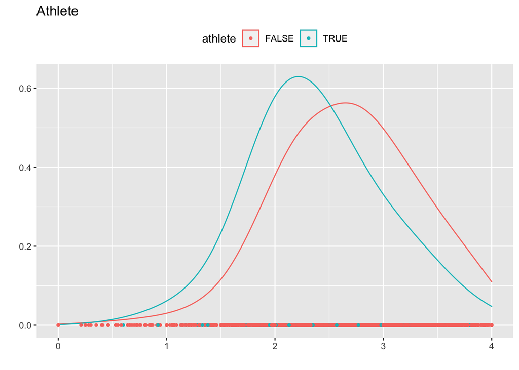

```r
p22
```

At first sight, seems that if you’re an athlete, ther’e a peak of average notes slightly lower than non athletes. Let’s see it from a boxplot:

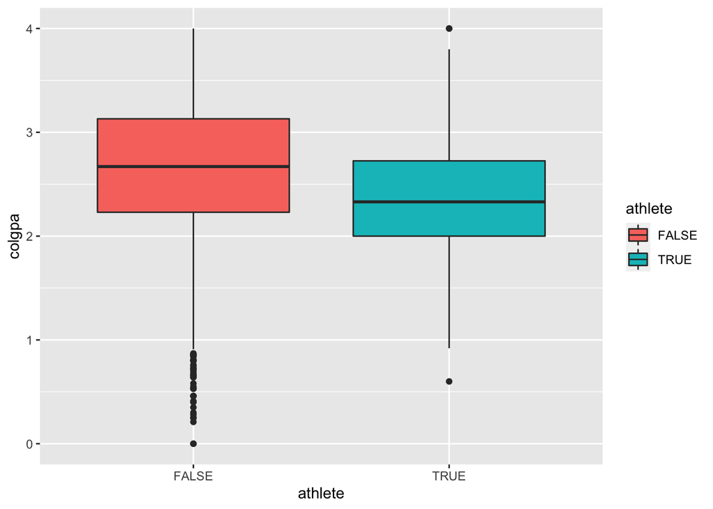

```r
ggplot(data = gpa, aes(x=athlete, y=colgpa)) + geom_boxplot(aes(fill=athlete))
```

### 4.2 Function for the contrast of averages:

Creating the function:

```r
ttestfunction <- function(x1, x2, CL=0.95, equalvar=TRUE, alternative="bilateral"){
  mean1 <- mean(x1)
  n1 <- length(x1)
  sd1 <- sd(x1)
  mean2 <- mean(x2)
  n2 <- length(x2)
  sd2 <- sd(x2)
  if (equalvar==TRUE){
    s <- sqrt(((n1-1)*sd1^2 + (n2-1)*sd2^2)/(n1+n2-2))
    Sb <- s*sqrt(1/n1 + 1/n2)
    df <- n1 + n2 - 2
  }
  else{
    Sb <- sqrt(sd1^2/n1 + sd2^2/n2)
    denom <- ((sd1^2/n1)^2/(n1-1) + (sd2^2/n2)^2/(n2-2))
    df <- ((sd1^2/n1 + sd2^2/n2)^2) / denom
  }
  alfa <- (1 - CL)
  t <- (mean1 - mean2) / Sb
  if (alternative=="bilateral"){
    tcritical <- qnorm(alfa/2, lower.tail=FALSE)
    pvalue <- pnorm(abs(t), lower.tail=FALSE)*2
  }
  else if (alternative=="less"){
    tcritical <- qnorm(alfa, df, lower.tail=TRUE)
    pvalue <- pnorm(t, df, lower.tail=TRUE)
  }
  else{
    tcritical <- qnorm(alfa, lower.tail=FALSE)
    pvalue <- pnorm(t, lower.tail=FALSE)
  }
    info <- data.frame(t, tcritical, pvalue)
    info %>% kable() %>% kable_styling()
    return(info)
}
```

### 4.3 Research question

La pregunta seria: Els atletes tenen una nota mitja inferior a la nota mitja de les persones no atletes?

### 4.4 Null and alternative hypothesis

H0: μAthlete = μNoAthlete

H1: μAthlete < μNoAthlete

### 4.5 Justifying the test to apply

It is a test of two samples with unknown variances. As they have a normal distribution, it would be an unilateral test.

### 4.6 Calculation

Calculating and outputting the results in a table:

```r
if (!require('kableExtra')) install.packages('kableExtra'); library('kableExtra')
info <- ttestfunction(gpa$colgpa[gpa$athlete==TRUE], gpa$colgpa[gpa$athlete==FALSE], alternative="less")
info
```

```
##           t tcritical pvalue
## 1 -5.910309  4133.355      0
```

Checking the results:

```r
t.test(gpa$colgpa[gpa$athlete==TRUE], gpa$colgpa[gpa$athlete==FALSE], alternative="less")
```

```
##
##  Welch Two Sample t-test
##
## data:  gpa$colgpa[gpa$athlete == TRUE] and gpa$colgpa[gpa$athlete == FALSE]
## t = -6.4591, df = 216.76, p-value = 3.414e-10
## alternative hypothesis: true difference in means is less than 0
## 95 percent confidence interval:
##        -Inf -0.2119267
## sample estimates:
## mean of x mean of y
##  2.382732  2.667484
```

### 4.7 Test interpretation

The critical value for a 95% confidence interval, having a p-value of 0, we can reject the null hypothesis for the alternative one: the average grade of athletes is significantly lower than non athletes.

Another way of proving it is seeing the confidence intervals:

```r
ic95athlete <- IC(gpa$colgpa[gpa$athlete==TRUE], 95)
ic95noathlete <- IC(gpa$colgpa[gpa$athlete==FALSE], 95)
ic95athlete
```

```
## [1] 2.298272 2.467192
```

```r
ic95noathlete
```

```
## [1] 2.646944 2.688025
```

As there is no overlap, we can confirm that notes are significantly different.

# 5 Do females have better grades than males?

### 5.1 Visual analysis

Getting back a previous visualization:

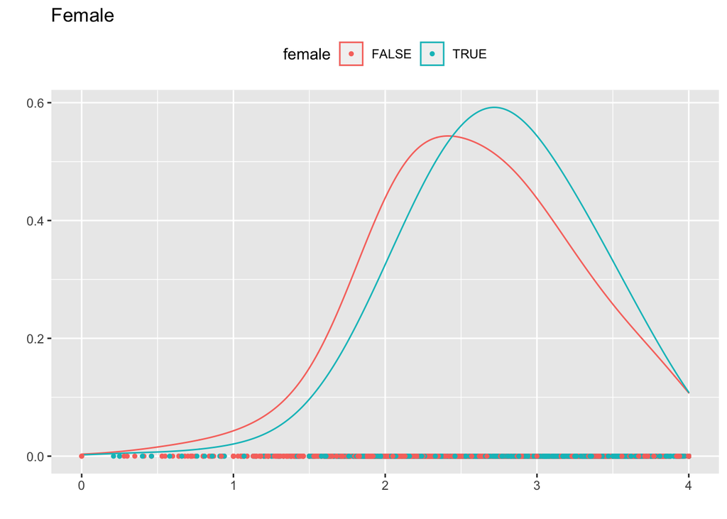

```r
p21
```

We can see that the peak of female notes is greater than the male one. Seeing it in a boxplot:

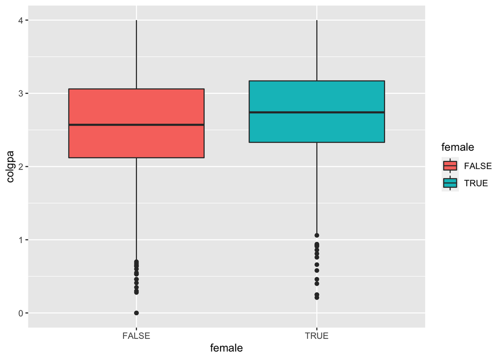

```r
ggplot(data = gpa, aes(x=female, y=colgpa)) + geom_boxplot(aes(fill=female))
```

### 5.2 Function

We will reuse the previous function.

### 5.3 Research question

Do females have a greater average grade than males?

### 5.4 Null and alternative hypothesis

H0: μFemale = μMale

H1: μFemale > μMale

### 5.5 Justifying the test to apply

It is a test of two samples with unkown variances. They have normal distributions. It is an unilateral test.

### 5.6 Calculation

For a 95% confidence interval:

```r
info2 <- ttestfunction(gpa$colgpa[gpa$female==TRUE], gpa$colgpa[gpa$female==FALSE], alternative="greater")
info2
```

```
##          t tcritical       pvalue
## 1 7.011716  1.644854 1.177066e-12
```

For a 90% confidence interval:

```r
info3 <- ttestfunction(gpa$colgpa[gpa$female==TRUE], gpa$colgpa[gpa$female==FALSE], CL=0.90, alternative="greater")
info3
```

```
##          t tcritical       pvalue
## 1 7.011716  1.281552 1.177066e-12
```

Checking the results:

```r
t.test(gpa$colgpa[gpa$female==TRUE], gpa$colgpa[gpa$female==FALSE], alternative="greater")
```

```
##
##  Welch Two Sample t-test
##
## data:  gpa$colgpa[gpa$female == TRUE] and gpa$colgpa[gpa$female == FALSE]
## t = 7.0787, df = 4087.4, p-value = 8.522e-13
## alternative hypothesis: true difference in means is greater than 0
## 95 percent confidence interval:
##  0.1100126       Inf
## sample estimates:
## mean of x mean of y
##  2.733016  2.589693
```

### 5.7 Test interpretation:

The critical value for a 95% condidence interval test, with a value of α=0.05 is 1.644854, and the observed value is 7.011716. Then, the accepted region for H0 is (-1.644854, 1.644854). As the observed value is outside that region, we can refute the null hypothesis stating that average grade of females is significantly greater than males. We should take this considerations with caution, as there are a lot of other cause that may produce this, such as socioeconomical factors.

It could also be validated by seeing the confidence interval:

```r
ic95female <- IC(gpa$colgpa[gpa$female==TRUE], 95)
ic95nofemale <- IC(gpa$colgpa[gpa$female==FALSE], 95)
ic95female
```

```
## [1] 2.704846 2.761186
```

```r
ic95nofemale
```

```
## [1] 2.561709 2.617676
```

As there is no overlap, we can state that the grades are significantly different between females and males.

# 6 Is there a difference in race?

### 6.1 Visual analysis

Creating a new column that contains if the race is white, black or NA if it’s another race.

```r
if (!require('tidyverse')) install.packages('tidyverse'); library('tidyverse')
gpa <- gpa %>% mutate(whiteblack = case_when(
  white == TRUE & black == FALSE ~ 'White',
  white == FALSE & black == TRUE ~ 'Black',
  white == FALSE & black == FALSE ~ 'NA',
))

gpa2 <- gpa2 %>% mutate(whiteblack = case_when(
  white == TRUE & black == FALSE ~ 'White',
  white == FALSE & black == TRUE ~ 'Black',
  white == FALSE & black == FALSE ~ 'NA',
))
```

Checking all is correct:

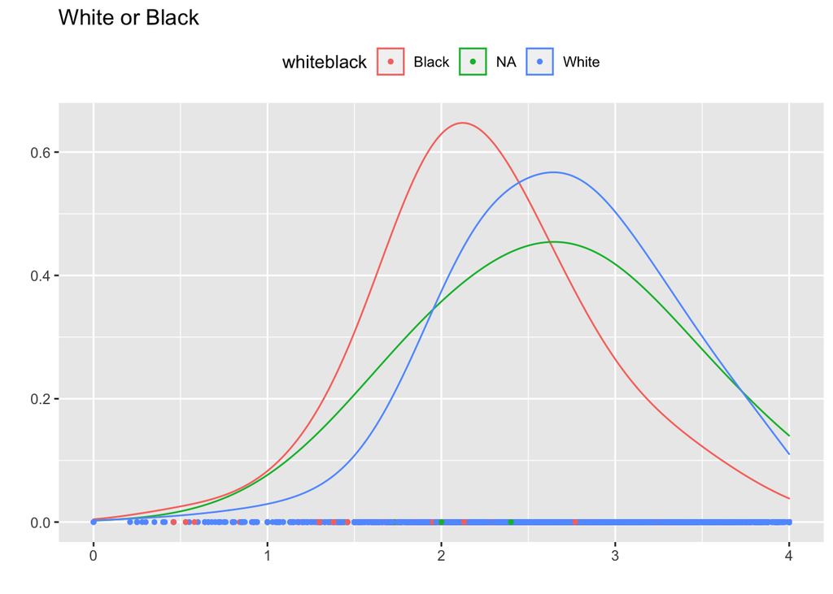

```r
p25<-ggplot(gpa2)+
  geom_density(aes(x= colgpa), adjust=2) +
  aes(colour = whiteblack) +
    labs(title="White or Black", y=" ", x=" " ) +
  theme(legend.position = "top")         +
  geom_point(aes(x=colgpa, y=ceros),  size=1)

p25
```

Seeing the distribution, we can see that, at first sight, white and NA have slighly higher values in colgpa. Let’s see it in a boxplot:

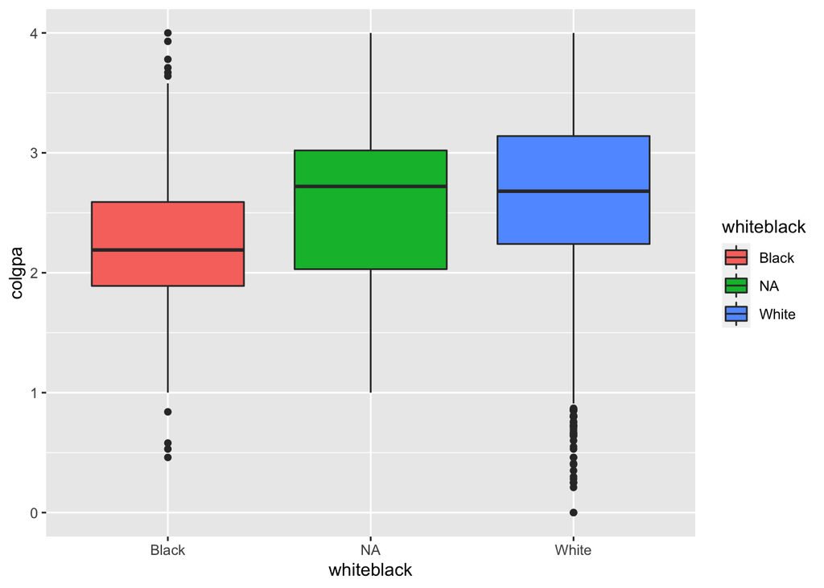

```r
ggplot(data = gpa, aes(x=whiteblack, y=colgpa)) + geom_boxplot(aes(fill=whiteblack))
```

We can see that there are outlires in black and white, as well as the average and the quartiles.

### 6.2 Function

We will reuse the previous function.

### 6.3 Research question

Are the notes of the white race equal with the black race?

### 6.4 Null and alternative hypothesis

H0: μWhite = μBlack

H1: μWhite ≠ μBlack

### 6.5 Justifying the test to apply

Having in consideration that the samples have a normal distribution, and the hypothesis that has been formulated, it is a bilateral test.

### 6.6 Calculation

Calculating at 95% confidence interval:

```r
info4 <- ttestfunction(gpa$colgpa[gpa$whiteblack=='White'], gpa$colgpa[gpa$whiteblack=='Black'], alternative="bilateral")
info4
```

```
##          t tcritical       pvalue
## 1 9.559319  1.959964 1.185339e-21
```

Checking the results:

```r
t.test(gpa$colgpa[gpa$whiteblack=='White'], gpa$colgpa[gpa$whiteblack=='Black'], alternative="two.sided")
```

```
##
##  Welch Two Sample t-test
##
## data:  gpa$colgpa[gpa$whiteblack == "White"] and gpa$colgpa[gpa$whiteblack == "Black"]
## t = 10.08, df = 259.7, p-value < 2.2e-16
## alternative hypothesis: true difference in means is not equal to 0
## 95 percent confidence interval:
##  0.3402153 0.5054127
## sample estimates:
## mean of x mean of y
##  2.678360  2.255546
```

### 6.7 Test interpretation

The critical value for the 95% confidence interval is 1.959964 and the observed value is 9.559319, so we can reject the null hypothesis of equal notes between races with a confidence interval of 95%, meaning that notes between races are not equal. We should take this considerations with caution, as there are a lot of other cause that may produce this, such as socioeconomical factors.

# 7 Athlete proportion

### 7.1 Visual analysis

Let’s see the proportion on a pie chart:

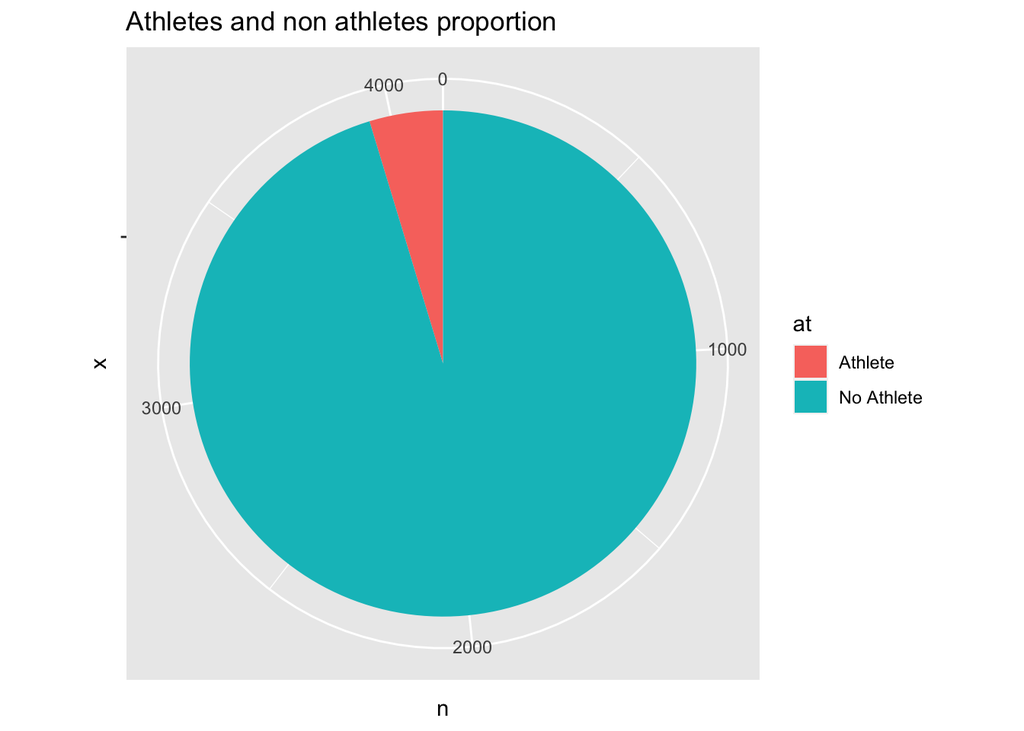

```r
athletes <- gpa[gpa$athlete == TRUE,]
noathletes <- gpa[gpa$athlete == FALSE,]

pie <- data.frame( at=c("Athlete", "No Athlete"), n=c(nrow(athletes), nrow(noathletes)))
ggplot(pie) +
  aes(x = "", y = n, fill = at) +
  geom_bar(stat = "identity", width = 1) +
  coord_polar("y", start = 0) +
  labs(title = "Athletes and non athletes proportion")
```

There are more non athletes than athletes

### 7.2 Research question

Is the proportion of athletes less thatn 0.05?

### 7.3 Hipòtesi nul·la i alternativa

H0 : pAthletes = 0.05 H1 : pAthletes < 0.05

### 7.4 Justificació del test a aplicar

Is a test of the proportion of a sample. The contrast is unliateral. We will apply the contrast of a sample for the proportion, assuming the binomial distribution aproximation ot a normal distribution for large sample sizes.

### 7.5 Calculating the test:

Defining a function to be used:

```r
proptest <- function(p, p0, n, CL = 95, alternative = "bilateral"){
  z <- (p - p0)/sqrt((p0 * (1 - p0)/n))
  alfa <- 1 - CL/100
  if (alternative == "bilateral"){
    pvalue <- pnorm(abs(z), lower.tail = FALSE)*2
    zcritical <- qnorm(alfa/2, lower.tail = FALSE)
  }
  else if (alternative == "less"){
    pvalue <- pnorm(z, lower.tail = TRUE)
    zcritical <- qnorm(alfa, lower.tail = TRUE)
  }
  else{
    pvalue <- pnorm(z, lower.tail = FALSE)
    zcritical <- qnorm(alfa, lower.tail = FALSE)
  }

  info <- c(p, p0, z, zcritical, pvalue)
  names(info) <- c("p", "p0", "z", "zcritical", "pvalue")
  return(info)
}
```

Using the funciton:

```r
info5 <- proptest(nrow(athletes)/nrow(gpa), p0 = 0.05, nrow(gpa), alternative = "less")
info5
```

```
##           p          p0           z   zcritical      pvalue
##  0.04689388  0.05000000 -0.91667115 -1.64485363  0.17965749
```

Checking the results:

```r
prop.test(x=nrow(athletes), n=nrow(gpa), p = 0.05, alternative = "less", correct = FALSE)
```

```
##
##  1-sample proportions test without continuity correction
##
## data:  nrow(athletes) out of nrow(gpa), null probability 0.05
## X-squared = 0.84029, df = 1, p-value = 0.1797
## alternative hypothesis: true p is less than 0.05
## 95 percent confidence interval:
##  0.00000000 0.05260282
## sample estimates:
##          p
## 0.04689388
```

# 8 Are there more athletes on males than females?

We create a new dataset only filtering athletes:

```r
gpa3 <- filter(gpa, athlete == TRUE)
```

### 8.1 Visual analysis.

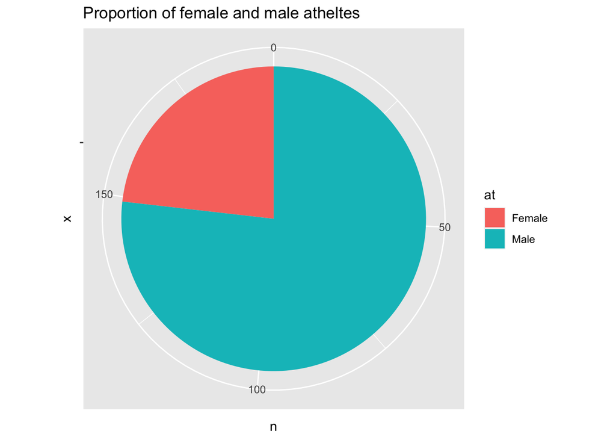

```r
females <- gpa3[gpa3$female == TRUE,]
males <- gpa3[gpa3$female == FALSE,]

pie2 <- data.frame( at=c("Female", "Male"), n=c(nrow(females), nrow(males)))
ggplot(pie2) +
  aes(x = "", y = n, fill = at) +
  geom_bar(stat = "identity", width = 1) +
  coord_polar("y", start = 0) +
  labs(title = "Proportion of female and male atheltes")
```

Looks like there are more male atheltes.

### 8.2 Research question

Are there more male than female athletes?

### 8.3 Hipòtesi nul·la i alternativa

H0 : pAthletesMale = pAthletesFemale H1 : pAthletesMale > pAthletesFemale

### 8.4 Justifying the test to apply

We can see that the contrast is unilateral, considering the alternative hypothesis. We will apply the contrast of a sample agianst the proportion, assuming the aproximation of a binomial distribution to a normal distribution for large samples.

### 8.5 Calculations of the test

Reusing the previously defined function:

```r
info6 <- proptest(nrow(males)/nrow(gpa3), p0 = 0.05, nrow(gpa3), alternative = "greater")
info6
```

```
##          p         p0          z  zcritical     pvalue
##  0.7680412  0.0500000 45.8884561  1.6448536  0.0000000
```

Checking the results:

```r
prop.test(x=nrow(males), n=nrow(gpa3), p = 0.05, alternative = "greater", correct = FALSE)
```

```
##
##  1-sample proportions test without continuity correction
##
## data:  nrow(males) out of nrow(gpa3), null probability 0.05
## X-squared = 2105.8, df = 1, p-value < 2.2e-16
## alternative hypothesis: true p is greater than 0.05
## 95 percent confidence interval:
##  0.7147161 1.0000000
## sample estimates:
##         p
## 0.7680412
```

### 8.6 Interpretació del test

Considering that the p-value is 0, we can discard the null hypothesis in favor of the alternative one, so it can be concluded that there are more male thatn female athletes with a 95% of confidence.